# Introduction to R

## Getting Started

- This workshop is a part of the [UConn Sports Analytics Symposium 2020](https://statds.org/events/ucsas2020/workshops.html).
- The source codes and necessary documentations are available at the repository: (https://github.com/mdtuhinsheikh/introR_ucsas2020).
- The workshop slides are available at the [link](https://mdtuhinsheikh.github.io/introR_ucsas2020/).
- Prerequisites:
  - [R](https://cran.r-project.org/) and [Rstudio](https://www.rstudio.com/products/rstudio/download/#download) have been installed.

## About Me

- Fourth year Ph.D. Student in Statistics, UConn.
- **Research Interests:**
  - Competing risks, longitudinal data, and cure rate modelling.
  - Bayesian statistics, co-data analysis, and model assessment.
  - Deep learning in survival data.
  - Interim data and microbiome data analysis.
- **Future goals:**
  - Contribute to the broader field of biostatistics through methodological developments.
- **Personal Website:** [link](https://www.isrt.ac.bd/people/tsheikh/).

## Workshop Pre-requisits

- Have little to NO experience with R.
- Enthusiastic attitude towards learning R programming.

## Aims of the Workshop

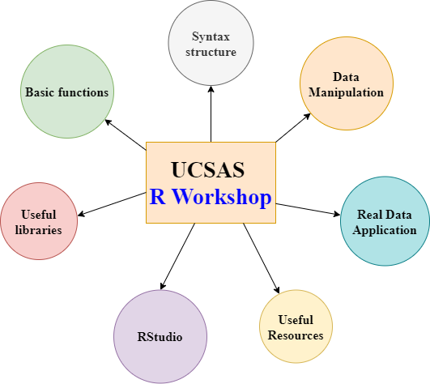

## Outline

- R Basics
- File System and Data Structure
- Read and Write Data
- Data Management
- Brief overview of “dplyr” package

## What is R?

- R is a free software environment for statistical computing and graphics
- R is a full-featured statistical analysis package (like SAS, SPSS, etc.) that allows to:
  - import, export, and manipulate data
  - represent data graphically
  - analyse and report
- Why the Name “R”?
  - Initial of the names of two originators: Ross Ihaka and Robert Gentleman
- More details: https://www.r-project.org.

## Why Learn R?

[figure not shown]

## IDE for R

- **RStudio** is an integrated development environment (IDE) for the R programming language.
- Let us introduce with the RStudio interface.

## RStudio interface

[figure not shown]

## R as a calculator

```r
5+7                          # 12

exp(5)                       # 148.4132

log(2)                       # 0.6931472
```

## Ask for help?

- **`?function_name`**, e.g.,

```r
?mean                       # Search mean function
```

- **`help.search("text")`**, e.g.,

```r
help.search("print")
```

- **Google** search engine or **Stack Overflow** are always excellent resources.

## Assigning operator

- We can assign values to a variable in R by using `<-` or `=` or `->`. For example,

```r
x <- "Hello World"
x                 # [1] "Hello World"
x = 5
x                 # [1] 5
5 -> x
x                 # [1] 5
```